# WhoTracks.me - Study Replication

Karlo Lukic, lukic@wiwi.uni-frankfurt.de

2020-08-03

```r
# libs
library(magrittr)
library(data.table)
library(ggplot2)
```

# 1 Info

This analysis reproduces [WhoTracks.me paper](https://t.ly/rKI5)’s “Results” section. The analysis is done in the manner of stating a question that can be answered with the data. Links to citations from the paper that confirm replicated results are also included.

# 2 Data

```r
# load data
global_sites_DT <- readRDS('./data/global/sites_DT.rds')
global_trackers_DT <- readRDS('./data/global/trackers_DT.rds')
global_companies_DT <- readRDS('./data/global/companies_DT.rds')
```

> “In this paper we present the WhoTracks.Me dataset, which contains aggregated data on third-party presence and tracking, released monthly. The data is generated by Ghostery and Cliqz users who have consented to anonymized HumanWeb data collection. This generates data on an average of 100 million page loads per month, increasing to over 300 million since April 2018, and currently spans 12 months.”

# 3 Snapshot in Time

> “We will be looking at the data from April 2018, composed of roughly 340 million page loads, and filtering the top 1330 most visited websites.”

## 3.1 Tracking stats (April 2018)

Subset time:

```r
# subset April 2018
global_sites_DT_apr_18 <- global_sites_DT[month=='2018-04-30']
unique(global_sites_DT_apr_18$month)
```

```
## [1] "2018-04-30"
```

What’s the total number of unique sites in this dataset?

```r
# filter top 1330 most visited sites
uniqueN(global_sites_DT_apr_18, by='site')
```

```
## [1] 1330
```

What percentage of traffic to these sites contains tracking (by cookies & fingerprinting combined)?

```r
# 71% of traffic to these sites contains tracking
mean(global_sites_DT_apr_18$tracked)*100
```

```
## [1] 70.95958
```

What’s the avg. number of trackers per site?

```r
# average number of trackers per site is 8 (actually 9)
mean(global_sites_DT_apr_18$trackers)
```

```
## [1] 8.508872
```

What’s the avg. number of tracking requests per page load?

```r
# average number of tracking requests per page load is 17 (actually 18)
mean(global_sites_DT_apr_18$requests_tracking)
```

```
## [1] 17.66687
```

> “We measure that 71% of the traffic to these sites contains tracking. The average number of trackers per site is 8, and the average number of tracking requests per page load 17.”

## 3.2 Tracking by website categories

What’s the avg. number of trackers per website category in April 2018? What’s the avg. percentage of page loads where users are being tracked, per website category in April 2018?

```r
# subset:
# 1. avg. # of trackers
# 2. % of page loads tracked
# per site category
DT <- global_sites_DT_apr_18[, .(category, trackers, tracked)] # take 3 cols
DT <- DT[, lapply(.SD, mean), by = category][order(trackers, decreasing = T)] # take averages
DT[, tracked := tracked * 100] # to %
DT
```

```
##            category  trackers  tracked
## 1: News and Portals 12.808004 79.49793
## 2:       Recreation 11.174949 78.88049
## 3:       E-Commerce  9.480769 76.24988
## 4:    Entertainment  7.637113 68.77299
## 5:         Business  7.563133 70.23985
## 6:        Reference  5.694304 65.56056
## 7:            Adult  5.012459 58.29603
## 8:          Banking  3.239734 53.52814
## 9:       Government  1.996521 26.72562
```

Visualize avg. number of trackers & avg. % of being tracked per website category in April 2018.

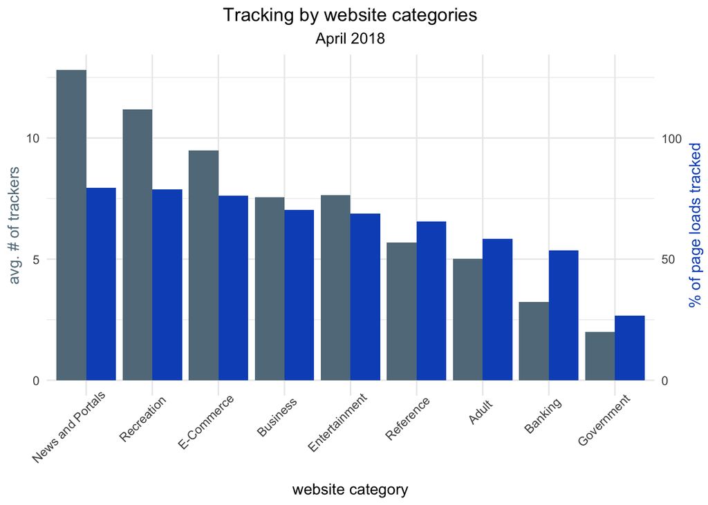

```r
# visualize
ggplot(DT, aes(x=reorder(category, -value), y=value, fill=variable)) +
  geom_bar(stat='identity', position='dodge') +
  hrbrthemes::scale_fill_ft() +
  scale_y_continuous(name= 'avg. # of trackers',
                     sec.axis = sec_axis(~ . * 10, name = '% of page loads tracked')) +
  labs(title = "Tracking by website categories", subtitle = 'April 2018', x = "website category") +
  theme_minimal() +
  theme(legend.position = "none",
        plot.title = element_text(hjust = 0.5), # center the title
        plot.subtitle = element_text(hjust = 0.5), # center the sub-title
        axis.text.x = element_text(angle = 45, hjust = 0.8), # add colors to text/axis
        axis.title.y.left = element_text(color="#627A88"),
        axis.title.y.right = element_text(color="#0954C2", angle = 90))
```

## 3.3 Top 10 trackers by reach and tracking

```r
# subset April 2018
global_trackers_DT_apr_18 <- global_trackers_DT[month=='2018-04-30']
```

What are top 10 trackers by reach?

```r
# subset top 10 trackers by reach
DT <- global_trackers_DT_apr_18[reach > 0.098] # approx. reach to get 10
DT <- DT[, .(tracker_name, reach, tracked)][order(reach, decreasing = T)] # take 3 cols
DT
```

```
##                  tracker_name      reach      tracked
##  1:          Google Analytics 0.45451019 0.1999292106
##  2:             Google Static 0.35601513 0.3527924123
##  3:        Google Tag Manager 0.30583757 0.0211177323
##  4:                    Google 0.29409389 0.6279519375
##  5:                  Facebook 0.28704291 0.4951029945
##  6:               DoubleClick 0.27611681 0.3873828239
##  7:              Google Fonts 0.24303521 0.0008152995
##  8:               Google APIs 0.15009331 0.0010663673
##  9:         Google AdServices 0.12958594 0.2689334074
## 10: ScoreCard Research Beacon 0.09825887 0.5795853581
```

Add `tracking_context` variable:

$$tracking\ context = reach \times tracked$$

```r
# add var: tracking_context
DT[, tracking_context := tracked * reach]
head(DT)
```

```
##          tracker_name     reach    tracked tracking_context
## 1:   Google Analytics 0.4545102 0.19992921      0.090869863
## 2:      Google Static 0.3560151 0.35279241      0.125599437
## 3: Google Tag Manager 0.3058376 0.02111773      0.006458596
## 4:             Google 0.2940939 0.62795194      0.184676825
## 5:           Facebook 0.2870429 0.49510299      0.142115802
## 6:        DoubleClick 0.2761168 0.38738282      0.106962911
```

Visualize the top 10 trackers by reach (presence) and their loads in tracking/non-tracking contexts.

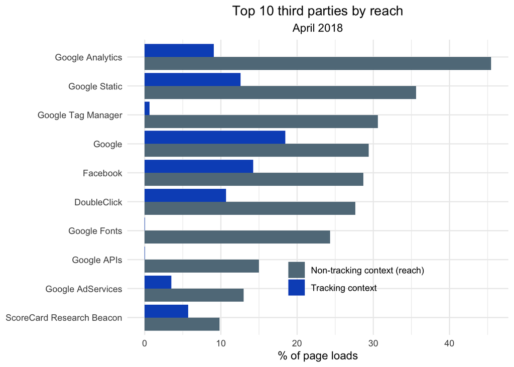

```r
# visualize
ggplot(DT) +
 aes(x = reorder(tracker_name, dplyr::desc(tracker_name)), fill = variable, weight = value) +
 geom_bar(position = "dodge") +
 hrbrthemes::scale_fill_ft(labels = c("Non-tracking context (reach)", "Tracking context")) +
 coord_flip() +
 theme_minimal() +
 labs(title = "Top 10 third parties by reach",
      subtitle = 'April 2018',
      x = NULL,
      y = '% of page loads',
      fill = NULL) +
  theme(legend.position = c(0.6,0.2),
        plot.title = element_text(hjust = 0.5), # center the title
        plot.subtitle = element_text(hjust = 0.5)) # center the sub-title
```

> “…Google Analytics has the highest reach, being present on roughly 46% of the measured web traffic, and 8 out of the top 10 third parties are operated by Google. …Google APIs is mostly used to load other 3rd parties such as Google Fonts and other static scripts, which is why we see it largely operating in a non-tracking context.”

## 3.4 Top 10 companies by reach and tracking

What are the top 10 companies by reach and tracking?

```r
# subset April 2018
global_companies_DT_apr_18 <- global_companies_DT[month=='2018-04-30']

# subset top 10 trackers by reach
DT <- global_companies_DT_apr_18[reach > 0.055] # approx. reach to get 10
DT <- DT[, .(month, company_name, reach, tracked)][order(reach, decreasing = T)] # take 3 cols
head(DT)
```

```
##         month   company_name      reach    tracked
## 1: 2018-04-30         Google 0.81467399 0.47723273
## 2: 2018-04-30       Facebook 0.28933930 0.50856211
## 3: 2018-04-30         Amazon 0.17119695 0.09996357
## 4: 2018-04-30 comScore, Inc. 0.09869937 0.57701576
## 5: 2018-04-30        Twitter 0.09065189 0.50081700
## 6: 2018-04-30         Criteo 0.07501759 0.36491771
```

Add `tracking_context` again.

```r
# add var: tracking_context
DT[, tracking_context := tracked * reach][]
```

```
##          month   company_name      reach    tracked tracking_context
##  1: 2018-04-30         Google 0.81467399 0.47723273       0.38878909
##  2: 2018-04-30       Facebook 0.28933930 0.50856211       0.14714701
##  3: 2018-04-30         Amazon 0.17119695 0.09996357       0.01711346
##  4: 2018-04-30 comScore, Inc. 0.09869937 0.57701576       0.05695109
##  5: 2018-04-30        Twitter 0.09065189 0.50081700       0.04540001
##  6: 2018-04-30         Criteo 0.07501759 0.36491771       0.02737525
##  7: 2018-04-30      Microsoft 0.06603503 0.61848061       0.04084139
##  8: 2018-04-30          Adobe 0.06581773 0.40134162       0.02641539
##  9: 2018-04-30         Oracle 0.05822488 0.49979504       0.02910051
## 10: 2018-04-30  AppNexus Inc. 0.05756285 0.22534216       0.01297134
```

Visualize the top 10 tracking companies by reach (presence) and their loads in tracking/non-tracking contexts.

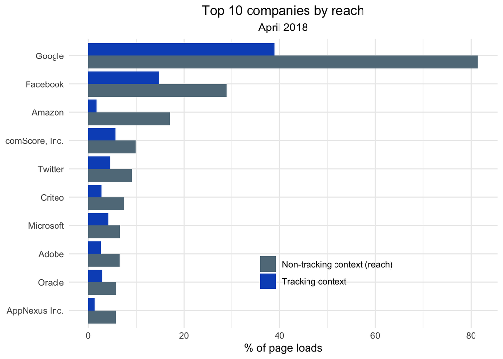

```r
# visualize
ggplot(DT) +
 aes(x = reorder(company_name, dplyr::desc(company_name)), fill = variable, weight = value) +
 geom_bar(position = "dodge") +
 hrbrthemes::scale_fill_ft(labels = c("Non-tracking context (reach)", "Tracking context")) +
 coord_flip() +
 theme_minimal() +
 labs(title = "Top 10 companies by reach",
      subtitle = 'April 2018',
      x = NULL,
      y = '% of page loads',
      fill = NULL) +
  theme(legend.position = c(0.6,0.2),
        plot.title = element_text(hjust = 0.5), # center the title
        plot.subtitle = element_text(hjust = 0.5)) # center the sub-title
```

> “…third-party scripts owned by Google are present in about 82% of the measured web traffic, and operate in a tracking context for slightly less than half that time. Facebook and Amazon follow next, and generally the distribution of reach by organisation…has a long tail.”

## 3.5 3p counts and block rates by category

What effect do ad-blockers have on trackers? What tracker categories are most impacted by ad-blockers?

```r
# subset April 2018
# filter out "Unknown" tracker categories
global_trackers_DT_apr_18 <- global_trackers_DT[month=='2018-04-30' & tracker_category != 'Unknown']

# subset 4 vars: tracker_name, tracker_category, reach, has_blocking
DT <- global_trackers_DT_apr_18[, .(tracker_name, tracker_category, reach, has_blocking)]

# group metrics: n_trackers, avg. amount of page loads blocked
DT <- DT[, .(n_trackers = uniqueN(tracker_name),  # get summary stats
       avg_pct_page_loads_blocked = mean(has_blocking*100)), by='tracker_category']
DT <- DT[order(avg_pct_page_loads_blocked, decreasing = T)] # order by blocking

# round %
DT[, avg_pct_page_loads_blocked := as.integer(avg_pct_page_loads_blocked*10)]

# print
head(DT)
```

```
##      tracker_category n_trackers avg_pct_page_loads_blocked
## 1:  Adult advertising         27                        433
## 2:        Advertising        417                        364
## 3:           Comments          5                        314
## 4:          Essential         25                        225
## 5:       Social media         22                        208
## 6: Audio video player         19                        199
```

Visualize third-parties and their average block rates by category.

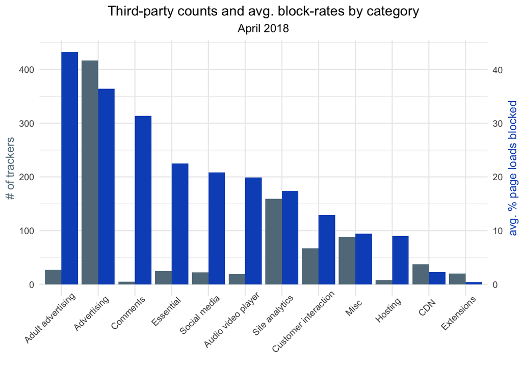

```r
# visualize
ggplot(DT) +
  aes(x = tracker_category, fill = variable, weight = value) +
  geom_bar(position = "dodge") +
  hrbrthemes::scale_fill_ft() +
  scale_y_continuous(
    name = "# of trackers",
    sec.axis = sec_axis(~ . / 10, name = "avg. % page loads blocked")
  ) +
  labs(title = "Third-party counts and avg. block-rates by category", subtitle = "April 2018", x = NULL, fill = NULL) +
  theme_minimal() +
  theme(
    legend.position = "none",
    plot.title = element_text(hjust = 0.5), # center the title
    plot.subtitle = element_text(hjust = 0.5), # center the sub-title
    axis.text.x = element_text(angle = 45, hjust = 0.8), # add colors to text/axis
    axis.title.y.left = element_text(color = "#627A88"),
    axis.title.y.right = element_text(color = "#0954C2", angle = 90)
  )
```

## 3.6 Malacius trackers

What trackers are possible malacius trackers that could perform man-in-the-middle attacks?

```r
# find MITM trackers
# subset April 2018
# filter out "Unknown" tracker categories
global_trackers_DT_apr_18 <- global_trackers_DT[month=='2018-04-30' & tracker_category != 'Unknown']
```

Add variable `reach_to_site_reach` (tracker’s presence redefined):

$$reach\ to\ site\ reach\ ratio= \frac{reach}{site\ reach}$$

```r
# add var: reach_to_site_reach
global_trackers_DT_apr_18[, reach_to_site_reach := round(reach / site_reach, digits = 2)]
global_trackers_DT_apr_18[, .(month, tracker_name, reach, site_reach, reach_to_site_reach)]
```

```
##           month       tracker_name        reach   site_reach
##   1: 2018-04-30   Google Analytics 4.545102e-01 7.404801e-01
##   2: 2018-04-30      Google Static 3.560151e-01 5.611084e-01
##   3: 2018-04-30 Google Tag Manager 3.058376e-01 2.986989e-01
##   4: 2018-04-30             Google 2.940939e-01 4.922811e-01
##   5: 2018-04-30           Facebook 2.870429e-01 4.060916e-01
##  ---
## 890: 2018-04-30             VIVALU 1.397553e-05 2.775482e-05
## 891: 2018-04-30       Programattik 1.389931e-05 1.094773e-04
## 892: 2018-04-30     stayfriends.de 1.371168e-05 1.264386e-04
## 893: 2018-04-30       4finance.com 1.016429e-05 1.264386e-04
## 894: 2018-04-30             Scoota 3.887467e-06 4.934190e-05
##      reach_to_site_reach
##   1:                0.61
##   2:                0.63
##   3:                1.02
##   4:                0.60
##   5:                0.71
##  ---
## 890:                0.50
## 891:                0.13
## 892:                0.11
## 893:                0.08
## 894:                0.08
```

Table of popular trackers, present only on a few sites.

```r
# find very popular trackers, present only on a few sites
DT <- global_trackers_DT_apr_18[reach_to_site_reach >= 20]
DT <- DT[, .(tracker_name, tracker_category, company, reach_to_site_reach)]
gt::gt(DT) %>%
  gt::tab_header(title='Highly popular trackers, present on minority of sites',
             subtitle = 'April 2018')
```

Highly popular trackers, present on minority of sites

April 2018

| tracker_name | tracker_category | company | reach_to_site_reach |
| --- | --- | --- | --- |
| DoublePimp | Adult advertising | doublepimp | 28.82 |
| Adomik | Advertising | unknown | 27.44 |
| Schibsted Media Group | Misc | schibsted_asa | 21.76 |
| Twitter for Business | Advertising | twitter | 55.51 |
| Digital Nomads | Advertising | unknown | 24.96 |
| Media Impact | Advertising | media_impact | 27.22 |

Table of unpopular trackers, present on large variety of sites.

```r
# find unpopular trackers, present on a large number of sites (proxy for malacious software)
DT <- global_trackers_DT_apr_18[reach_to_site_reach <= 0.10]
DT <- DT[, .(tracker_name, tracker_category, company, reach_to_site_reach)]
gt::gt(DT) %>%
  gt::tab_header(title='Unpopular trackers, present on large number of sites (possibly malacious extensions)',
             subtitle = 'April 2018')
```

Unpopular trackers, present on large number of sites (possibly malacious extensions)

April 2018

| tracker_name | tracker_category | company | reach_to_site_reach |
| --- | --- | --- | --- |
| worldnaturenet.xyz | Extensions | unknown | 0.10 |
| eluxer.net | Extensions | unknown | 0.10 |
| glganltcs.space | Extensions | unknown | 0.10 |
| pmddby.com | Extensions | unknown | 0.10 |
| Yandex.Advisor | Extensions | yandex | 0.10 |
| ActStream | Extensions | unknown | 0.09 |
| dcbap.com | Extensions | unknown | 0.10 |
| eshopcomp.com | Extensions | unknown | 0.10 |
| davebestdeals.com | Extensions | unknown | 0.08 |
| iRobinHood | Extensions | unknown | 0.08 |
| Fyber | Advertising | fyber | 0.10 |
| SimilarDeals | Misc | unknown | 0.08 |
| Webgains | Misc | unknown | 0.09 |
| Active Agent | Advertising | active_agent | 0.10 |
| congstar.de | Advertising | unknown | 0.10 |
| foxydeal.com | Extensions | unknown | 0.10 |
| marshadow.io | Advertising | unknown | 0.08 |
| Lenua System | Advertising | synatix | 0.05 |
| 4finance.com | Customer interaction | unknown | 0.08 |
| Scoota | Advertising | rockabox | 0.08 |

```r
# filter to find "worlnaturenet.xyz" % eluxer.net
# you're being tracked more than 70% of the time, low avg. N of HTTP requests, higher reach, low RTST ratio
# DT[tracked >= .7][reach>=.001][requests <= 5][reach_to_site_reach <= 0.1]
```

> “Take the example of DoublePimp with a a reach to site reach ratio of 28.8 …, typically present on adult sites, and particularly in a few popular ones. Similarly, `eluxer.net`, with a reach to site reach ratio of 0.1, is a malicious extension which does insert tracking.”

# 4 Longitudinal

## 4.1 HTTPS Adoption

What was the avg. third-party HTTPS adoption of most visited sites in May 2017 vs. April 2018?

```r
# prepare data
# sites
# subset May 2017 & April 2018, take 3 vars
global_sites_DT_may_17 <- global_sites_DT[month=='2017-05-31', .(month, site, category, popularity, https)]
global_sites_DT_apr_18 <- global_sites_DT[month=='2018-04-30', .(month, site, category, popularity, https)]
```

```r
# compare avg. 3p HTTPS adoption on all top sites: May 2017
https_adopt_top_sites_may_17 <-
  global_sites_DT_may_17[, .(avg_https_adoption_top_sites = mean(https))]
https_adopt_top_sites_may_17
```

```
##    avg_https_adoption_top_sites
## 1:                    0.5666519
```

```r
# compare avg. 3p HTTPS adoption on all top sites: April 2018
https_adopt_top_sites_apr_18 <-
global_sites_DT_apr_18[, .(avg_https_adoption_top_sites = mean(https))]
https_adopt_top_sites_apr_18
```

```
##    avg_https_adoption_top_sites
## 1:                    0.8108948
```

What was the avg. third-party HTTPS adoption of news sites in May 2017 vs. April 2018?

```r
# compare avg. 3p HTTPS adoption on news sites: May 17
https_adopt_news_sites_may_17 <-
  global_sites_DT_may_17[, .(avg_https_adoption_news_sites = mean(https)), by='category'][category=='News and Portals'][, -c('category')]
https_adopt_news_sites_may_17
```

```
##    avg_https_adoption_news_sites
## 1:                     0.2694462
```

```r
# compare avg. 3p HTTPS adoption on news sites: April 18
https_adopt_news_sites_apr_18 <-
global_sites_DT_apr_18[, .(avg_https_adoption_news_sites = mean(https)), by='category'][category=='News and Portals'][, -c('category')]
https_adopt_news_sites_apr_18
```

```
##    avg_https_adoption_news_sites
## 1:                     0.6791304
```

What was the avg. third-party HTTPS adoption of top trackers (Google, Facebook, AppNexus) and an outlier (Snowplow) in May 2017 vs. April 2018?

```r
# prepare data & functions
# trackers
# get May 2017 & April 2018 info,
# filter out "Unknown" tracker categories, take 3 vars: get_tracker_https_adoption
get_tracker_https_adoption_17 <- function(given_tracker_name) {
  global_trackers_DT[month=='2017-05-31' & tracker_category != 'Unknown', .(month, tracker_name, https)][tracker_name == (given_tracker_name), https]
}
get_tracker_https_adoption_18 <- function(given_tracker_name) {
  global_trackers_DT[month=='2018-04-30' & tracker_category != 'Unknown', .(month, tracker_name, https)][tracker_name == (given_tracker_name), https]
}

# compare avg. HTTPS adoption of 4 different trackers (operated by 4 diff. companies):
# 1. Google Analytics
# 2. Facebook
# 3. AppNexus
# 4. Snowplot (example for HTTPS adoption lag)
# get_tracker_https_adoption_17('Google Analytics')
# get_tracker_https_adoption_18('Google Analytics')
# get_tracker_https_adoption_17('Facebook')
# get_tracker_https_adoption_18('Facebook')
# get_tracker_https_adoption_17('AppNexus')
# get_tracker_https_adoption_18('AppNexus')
# get_tracker_https_adoption_17('Snowplow')
# get_tracker_https_adoption_18('Snowplow')
```

Pack metrics to a single table.

```r
# pack to DT
https_adopt_DT <- data.table(
  "Entity" = c(
    "Top sites", "News Sites",
    "Google Analytics", "Facebook", "AppNexus", "Snowplow"
  ),
  "May 2017" = as.numeric(c(
    https_adopt_top_sites_may_17, https_adopt_news_sites_may_17,
    get_tracker_https_adoption_17("Google Analytics"),
    get_tracker_https_adoption_17("Facebook"),
    get_tracker_https_adoption_17("AppNexus"),
    get_tracker_https_adoption_17("Snowplow"))
  ),
  "April 2018" = as.numeric(c(
    https_adopt_top_sites_apr_18, https_adopt_news_sites_apr_18,
    get_tracker_https_adoption_18("Google Analytics"),
    get_tracker_https_adoption_18("Facebook"),
    get_tracker_https_adoption_18("AppNexus"),
    get_tracker_https_adoption_18("Snowplow"))
  )
)

# add var: Change
https_adopt_DT[, Change := `April 2018` - `May 2017`]

# to table
gt::gt(https_adopt_DT) %>%
  gt::tab_header(
    title = "HTTPS Adoption of sites and trackers from May 2017 to April 2018",
  ) %>%
  gt::fmt_percent(
    columns = c("May 2017", "April 2018", "Change"),
    decimals = 1
  ) %>%
  gt::tab_spanner(
  label = "All 3rd party secure requests",
  columns = c("May 2017", "April 2018", "Change"))
```

HTTPS Adoption of sites and trackers from May 2017 to April 2018

| Entity | All 3rd party secure requests May 2017 | All 3rd party secure requests April 2018 | All 3rd party secure requests Change |
| --- | --- | --- | --- |
| Top sites | 56.7% | 81.1% | 24.4% |
| News Sites | 26.9% | 67.9% | 41.0% |
| Google Analytics | 64.0% | 84.2% | 20.3% |
| Facebook | 72.2% | 83.8% | 11.7% |
| AppNexus | 56.5% | 83.5% | 27.0% |
| Snowplow | 72.6% | 46.3% | −26.4% |

> “We can see a strong increase in sites which have all third-party content loaded over HTTPS, from 57% to 81%. Certain categories of site lag behind in this regard though, namely news sites. Looking at specific trackers, we can see dominant players such as Google Analytics and AppNexus successfully migrating clients to HTTPS over the year. Others, like Facebook, have had slower progress on this front. In general, trackers improved their HTTPS usage over this period, with only 65 trackers (of 587 with data at both time points) not increasing HTTPS coverage. A small number of outliers showed a negative trend, for example Snowplow, an analytics provider present on major news websites, including Le Monde and New York Times.”

## 4.2 Cost imposed on users

How “taxing” are trackers? In other words, what impact trackers have on user experience while they browse web pages? How much do they slow down the loading of websites?

```r
# subset April 2018 & May 2017
global_sites_DT_apr_18 <- global_sites_DT[month=='2018-04-30']
global_sites_DT_may_17 <- global_sites_DT[month == '2017-05-31']
```

What was the avg. number of third-party tracking requests per page load in April 2018 vs. May 2017?

April 2018:

```r
# average number of tracking requests per page load is 17 (actually 18) in Apr 18
round(mean(global_sites_DT_apr_18$requests_tracking), 2)
```

```
## [1] 17.67
```

May 2017:

```r
# average number of tracking requests per page load is 35 in May 17
round(mean(global_sites_DT_may_17$requests_tracking), 2)
```

```
## [1] 35.1
```

Measure the amount of data needed to load third-party content, i.e. the [“Tracker Tax”](https://t.ly/ofU0):

> “We take the sum of the Content-Length of all third-party requests in the top 1330 websites over the last year, and measure the variation in this data consumption over time.”

April 2018:

```r
# get content_length stats: measure given in Bytes ( / 1000000 to Megabytes)
global_sites_DT_apr_18[, .(content_length), by=site][, summary(content_length / 1000000)]
```

```
##     Min.  1st Qu.   Median     Mean  3rd Qu.     Max.
##   0.0061   0.1831   0.4285  11.4827   1.5003 908.5082
```

May 2017:

```r
global_sites_DT_may_17[, .(content_length), by=site][, summary(content_length / 1000000)]
```

```
##      Min.   1st Qu.    Median      Mean   3rd Qu.      Max.
##     0.008     0.245     0.585   118.703     1.804 22825.532
```

> “The median content length per site from third parties was 0.42MB with an interquartile range (IQR) of 0.18-1.5MB [in April 2018], down from 0.58MB (IQR 0.24-1.8MB) a year earlier. The distribution has a long tail due to third parties offering Audio Video player services being part of the data.”

## 4.3 Tracking technologies over time

How Google Analytics operated its tracking in April 2018? How was the tracking done?

```r
# find Google Analytics info
global_trackers_DT_apr_18[tracker=='google_analytics', .(tracker_name, script, image, beacon)]
```

```
##        tracker_name    script     image     beacon
## 1: Google Analytics 0.9705205 0.5013017 0.02595518
```

> “… we can see that, for example, during April 2018 Google Analytics loaded their [Java]script on each page load (97% of the time), then registered the visit via an image (pixel) on 50% of page loads. We also see that on 2.6% of pages a request is also made via the Beacon API.”

What are the most popular ways to track online users? How did these technologies change over time from the tracker’s perspective?

Visualize the usage of tracking technologies over time by third-parties.

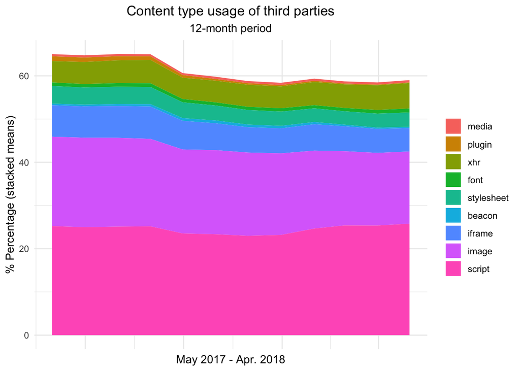

```r
# set order: script, image, iframe, beacon, stylesheet, font, xhr, plugin, media
factor_levels <- c('script', 'image', 'iframe', 'beacon', 'stylesheet', 'font', 'xhr', 'plugin', 'media')
DT$content_type <- factor(DT$content_type,
                          levels = rev(factor_levels))

# visualize
ggplot(DT) +
 aes(x = month, y = avg_value, fill = content_type) +
 geom_area(size = 1L) +
 scale_fill_hue() +
 labs(title= 'Content type usage of third parties', subtitle = '12-month period',
      x = "May 2017 - Apr. 2018", y = "% Percentage (stacked means)") +
 theme_minimal() +
 theme(plot.title = element_text(hjust = 0.5),
       plot.subtitle = element_text(hjust = 0.5),
       axis.text.x=element_blank(),
       axis.ticks.x=element_blank(),
       legend.title = element_blank())
```

> “… scripts and images are the most popular content types for tracking. Interestingly, beacons, originally designed to satisfy tracking use cases are encountered increasingly less.”

## 4.4 Change in avg. reach over time by type of third party

How did third-party reach change over time? Which tracker categories changed their reach the most?

Visualize change in avg. reach by tracker categories over time.

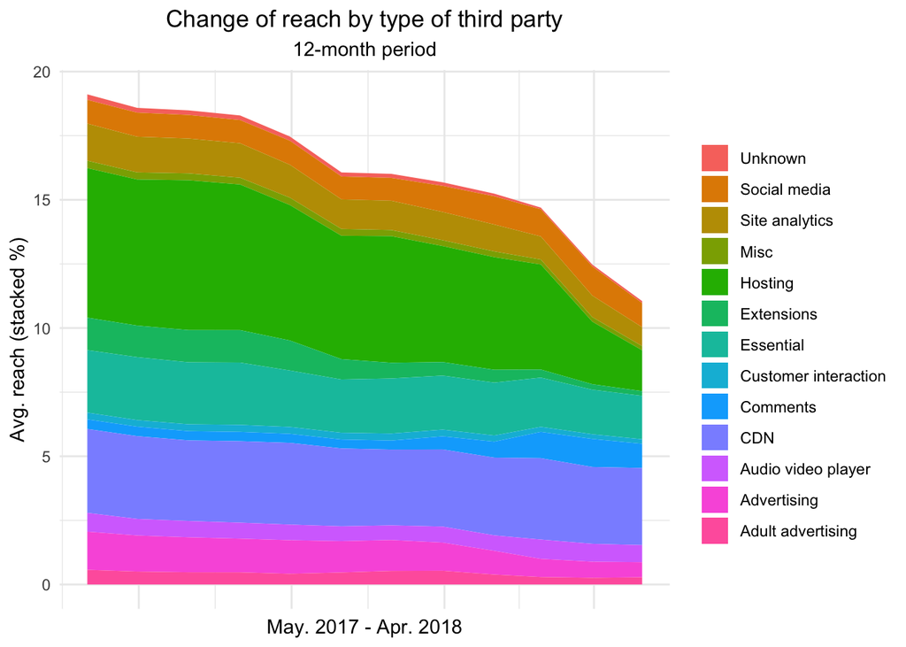

```r
# set fill order: script, image, iframe, beacon, stylesheet, font, xhr, plugin, media
factor_levels <- c('Unknown', 'Social media', 'Site analytics', 'Misc', 'Hosting', 'Extensions', 'Essential', 'Customer interaction', 'Comments', 'CDN', 'Audio video player', 'Advertising', 'Adult advertising')
DT$tracker_category <- factor(DT$tracker_category,
                          levels = factor_levels)

# visualize
ggplot(DT) +
 aes(x = month, y = avg_reach, fill = tracker_category) +
 geom_area(size = 1L) +
 scale_fill_hue() +
 labs(x = "May. 2017 - Apr. 2018", y = "Avg. reach (stacked %)", title = "Change of reach by type of third party", subtitle = "12-month period") +
 theme_minimal()+
 theme(plot.title = element_text(hjust = 0.5),
       plot.subtitle = element_text(hjust = 0.5),
       axis.text.x=element_blank(),
       axis.ticks.x=element_blank(),
       legend.title = element_blank())
```

> “If grouped and averaged … we observe almost an across-the-board decrease in the reach of third parties, most notably in the category of extensions that engage in MITM tracking. One explanation could be attributed to an increased adoption of ad-blockers. This analyses can be conducted at a more fine granular level, by monitoring the change in the average number of third parties in any given site.”

## 4.5 Change in avg. number of third parties over time on The Guardian and Le Figaro

Focus on more granural differences: visualize the change of avg. number of third-party trackers over time on two chosen sites – The Guardian and Le Figaro.

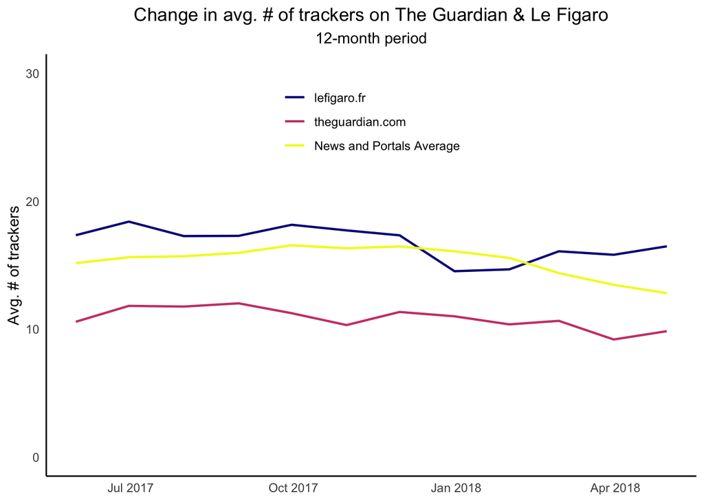

```r
# visualize
ggplot(DT) +
 aes(x = month, y = avg_n_trackers, color = variable) +
 geom_line(size = 0.78) +
 scale_color_viridis_d(option = "plasma") +
 labs(x = NULL, y = "Avg. # of trackers", title = "Change in avg. # of trackers on The Guardian & Le Figaro", subtitle = "12-month period") +
 ylim(0, 30) +
 theme_minimal()+
 theme(legend.position = c(0.5,0.85),
       plot.title = element_text(hjust = 0.5),
       plot.subtitle = element_text(hjust = 0.5),
       #axis.text.x=element_blank(),
       #axis.ticks.x=element_blank(),
       legend.title = element_blank(),
       #panel.border = element_blank(),
       panel.grid.major = element_blank(),
       panel.grid.minor = element_blank(),
       axis.line = element_line(colour = "black"))
```